# Watching a fit unfold: streaming callbacks

# Why watch a fit live?

In MCMC Diagnostics we inspect a chain *after* it finishes: trace plots, R̂, ESS, divergence counts. That works well for the small models in this course, which fit in seconds. For a slow model — a stiff ODE, a particle filter likelihood, a joint model over several data streams — a single fit can take minutes to hours. Waiting that long only to discover the chain never moved, got stuck in one mode, or filled up with divergences is a slow way to debug.

The same pathologies usually show up within the first few hundred steps. If you can *watch* the log-density climb, the divergences tick up, or the chain stall while the fit is still running, you can stop early and adjust instead of waiting for the whole run. This page shows how to stream that information out of a Turing fit using a callback, and how to send it to [TensorBoard](https://www.tensorflow.org/tensorboard) for live curves.

**NoteWhere this comes from**

This pattern was lifted from a real joint model, epiforecasts/BVDOutbreakSize, where a streaming callback made a multimodal fitting pathology obvious in the first warmup steps rather than only after a long run had finished.

# The `callback=` hook

Every Turing sampler runs through AbstractMCMC.jl, which exposes a per-step `callback` keyword on `sample`. The callback is a function fired once per iteration, on every chain, with the current sampler state:

```julia
callback(rng, model, sampler, transition, state, iteration; kwargs...)
```

The interesting argument is `transition`. For NUTS it carries the per-step statistics we want to stream. Let’s load Turing and look at what a transition actually contains:

```julia
using Turing
using Plots
using Random
Random.seed!(20260604)

@model function wobble()
    x ~ Normal(0.0, 1.0)
    y ~ Normal(x, 1.0)
end
```

[output not shown]

```
wobble (generic function with 2 methods)
```

```julia
# A callback that just grabs the first transition so we can inspect it
captured = Ref{Any}(nothing)
peek = function (rng, model, sampler, transition, state, iteration; kwargs...)
    iteration == 1 && (captured[] = transition)
    return nothing
end

sample(wobble(), NUTS(), 20; callback = peek, progress = false)
```

The per-step statistics NUTS exposes are:

```julia
keys(captured[].stats)
```

```
(:n_steps, :is_accept, :acceptance_rate, :log_density, :hamiltonian_energy, :hamiltonian_energy_error, :max_hamiltonian_energy_error, :tree_depth, :numerical_error, :step_size, :nom_step_size, :logprior, :loglikelihood, :logjoint)
```

**TipCode explainer**

- `callback = peek` — the keyword that hooks our function into `sample`. It runs once per kept draw.
- `transition.stats` — a [named tuple](https://docs.julialang.org/en/v1/manual/functions/#Named-Tuples) of per-step diagnostics. The ones we care about are `logjoint` (the log-density), `numerical_error` (the divergence flag), `step_size`, and `acceptance_rate`.
- `Ref{Any}(nothing)` — a mutable box. The callback can’t return a value to us, so we stash the transition in a `Ref` to look at afterwards.

The exact contents of `transition.stats` depend on the sampler: NUTS reports Hamiltonian diagnostics, while a Metropolis sampler reports far fewer fields. Reading from `transition.stats` rather than reaching into private transition fields keeps the callback working across samplers.

# A simple progress recorder

The following closure records the iteration number, the log-density, and a running count of divergences each time it fires. It reads everything from `transition.stats`, and the whole body is wrapped in `try`/`catch` so a transition that doesn’t expose these fields can never abort the fit:

```julia
function progress_recorder(; every::Integer = 1)
    iters = Int[]
    lps = Float64[]
    divergences = Int[]
    ndiv = Ref(0)
    callback = function (rng, model, sampler, transition, state, iteration;
            kwargs...)
        try
            stats = transition.stats
            get(stats, :numerical_error, false) === true && (ndiv[] += 1)
            if iteration % every == 0
                push!(iters, iteration)
                push!(lps, get(stats, :logjoint, NaN))
                push!(divergences, ndiv[])
            end
        catch
            # A progress callback must never bring down a fit.
        end
        return nothing
    end
    return callback, (; iters, lps, divergences)
end
```

```
progress_recorder (generic function with 1 method)
```

**TipCode explainer**

- The function returns *two* things: the `callback` to pass to `sample`, and a named tuple of vectors it writes into as the fit runs.
- `ndiv = Ref(0)` — a running divergence tally the closure carries between calls. Each divergent transition bumps it.
- `every` — log only every nth step. Set it higher for long runs so the vectors don’t grow without bound.
- The same closure is called from every thread when you sample chains in parallel with `MCMCThreads()`. For a real parallel fit you’d guard the shared vectors with a `ReentrantLock`; here we keep one chain for clarity.

**NoteIsn’t there a built-in for this?**

Recent AbstractMCMC.jl (≥ 5.13) adds `mcmc_callback`, including a ready-made TensorBoard logging callback, so you don’t have to write the closure yourself. It relies on a newer `getparams`/`getstats` state interface than the Turing version pinned in this course implements, so it errors here — which is why we read `transition.stats` directly. The hand-written version is also easier to read when the point is to *see* what a callback does.

By default NUTS discards its warmup, so a callback only sees post-warmup draws. Passing `discard_adapt = false` keeps the adaptation steps and streams them too, so we can watch the log-density climb out of its starting point and the step size settle:

```julia
cb, rec = progress_recorder()
sample(
    wobble(), NUTS(), 200;
    callback = cb, num_warmup = 100, discard_adapt = false, progress = false
)
```

**Plotting code**

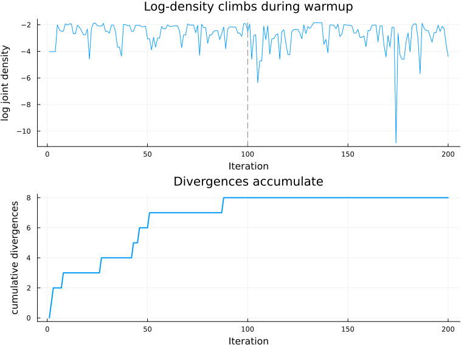

```julia
p1 = plot(
    rec.iters, rec.lps, xlabel = "Iteration", ylabel = "log joint density",
    title = "Log-density climbs during warmup", legend = false, linewidth = 1
)
vline!(p1, [100], color = :grey, linestyle = :dash)
p2 = plot(
    rec.iters, rec.divergences, xlabel = "Iteration",
    ylabel = "cumulative divergences",
    title = "Divergences accumulate", legend = false, linewidth = 2
)
plot(p1, p2, layout = (2, 1), size = (800, 600))
```

The dashed line marks the end of warmup. The log-density rises quickly from its arbitrary starting point and then fluctuates around a stable level once the chain reaches the typical set — exactly the “find the posterior, then explore it” behaviour described under burn-in and warmup. A handful of early divergences during adaptation is normal; a count that keeps climbing after warmup is the warning sign.

**TipGoing further: animate the fit as it samples**

The recorder above fills vectors to plot once the fit has finished. Because the callback fires every step, you can also draw *inside* it, capturing a frame each time so the trace grows as the sampler runs:

**Animation code**

```julia
anim = Animation()
lp_live = Float64[]
animate_cb = function (rng, model, sampler, transition, state, iteration;
        kwargs...)
    push!(lp_live, get(transition.stats, :logjoint, NaN))
    if iteration % 5 == 0
        plot(
            lp_live, xlim = (0, 200), xlabel = "Iteration",
            ylabel = "log joint density",
            title = "Fit in progress (step $iteration)",
            legend = false, linewidth = 1
        )
        frame(anim)
    end
    return nothing
end
sample(
    wobble(), NUTS(), 200;
    callback = animate_cb, num_warmup = 100, discard_adapt = false,
    progress = false
)
```

```
[ Info: Saved animation to /tmp/jl_EbCBqLStud.gif
```

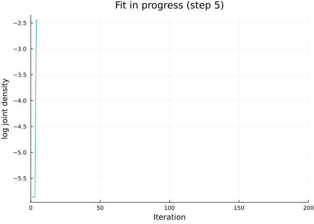

Live in a session this redraws a plot window as the fit runs; here it renders as the animation above. For a long fit, throttle the redraw (a larger `every`) so plotting doesn’t slow the sampler.

# Catching a pathology early

To see what a *bad* fit looks like through the same lens, here is [Neal’s funnel](https://mc-stan.org/docs/stan-users-guide/reparameterization.html), a posterior whose neck is so narrow that NUTS cannot navigate it without a tiny step size. Watch the divergence count:

```julia
@model function funnel()
    v ~ Normal(0, 3)
    x ~ Normal(0, exp(v / 2))
end

cb_f, rec_f = progress_recorder()
sample(funnel(), NUTS(0.6), 400; callback = cb_f, progress = false)
```

```julia
println("Divergent transitions: $(rec_f.divergences[end]) / 400")
```

```
Divergent transitions: 42 / 400
```

**Plotting code**

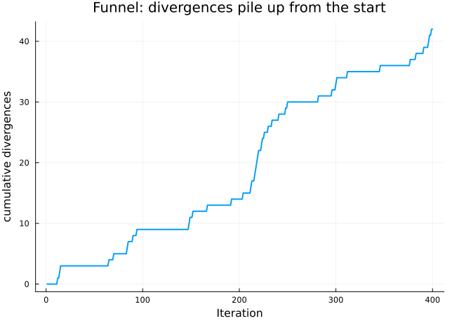

```julia
plot(
    rec_f.iters, rec_f.divergences, xlabel = "Iteration",
    ylabel = "cumulative divergences",
    title = "Funnel: divergences pile up from the start",
    legend = false, linewidth = 2
)
```

# Going further: live curves with TensorBoard

A recorder that fills vectors is enough to plot once a fit has finished. [TensorBoard](https://www.tensorflow.org/tensorboard) gives you the same curves *as the fit runs*, in a browser dashboard you can pan and zoom — and the same dashboard is a quick way to explore an **already-finished** fit without writing any plotting code, since it draws every logged scalar and a histogram of each for you.

The course ships a small helper, [`src/tensorboard_callback.jl`](https://github.com/sbfnk/mfiidd/blob/main/src/tensorboard_callback.jl), that logs each parameter and diagnostic to TensorBoard through TensorBoardLogger.jl. It is opt-in: TensorBoardLogger isn’t a course dependency, so you install it once (`] add TensorBoardLogger`) and load it before including the file. Being a plain source file, it is reusable anywhere the course calls `sample(...)` — drop it into the Particle MCMC session, for instance, to watch a PMMH run’s log-posterior and acceptance live.

**NoteUsing the TensorBoard helper (run this locally)**

The dashboard is interactive, so this is run on your own machine rather than when the page builds.

```julia
using TensorBoardLogger
include(joinpath(@__DIR__, "..", "src", "tensorboard_callback.jl"))

cb = tensorboard_callback("logs/run1")
sample(wobble(), NUTS(), 1000; callback = cb)
```

Then, in a terminal:

```bash
tensorboard --logdir logs/run1
```

Open the printed URL and the parameters and diagnostics (log-density, step size, tree depth, divergence flag) stream in as the fit runs, each as a scalar trace and a running histogram. To compare several chains, give each its own run directory (`logs/run1/chain1`, `logs/run1/chain2`, …) and point TensorBoard at the parent — it overlays the runs on one axis.

# When to reach for this

- **Fast models** (everything in the core sessions): the post-hoc diagnostics in MCMC Diagnostics are simpler and enough.
- **Slow models** where a fit takes minutes or more: a streaming callback lets you abort a doomed run early instead of waiting it out.
- **Debugging a new model**: watching the log-density and divergences from the first steps makes stuck chains, bad initialisation, and difficult geometry obvious quickly.

# References

- [AbstractMCMC.jl documentation](https://turinglang.org/AbstractMCMC.jl/stable/) — the `callback` interface used by every Turing sampler
- TensorBoardLogger.jl — logging scalars and histograms to TensorBoard from Julia
- [Neal (2003), Slice Sampling](https://doi.org/10.1214/aos/1056562461) — introduces the funnel as a hard sampling target
- [Betancourt (2017), A Conceptual Introduction to Hamiltonian Monte Carlo](https://arxiv.org/abs/1701.02434) — why divergences signal geometric problems